# Grad-CAM_demo

Part of MSc project. Involves using Grad-CAM to visualize which regions of an image were important for classification  
**[CLICK HERE](https://github.com/j-l-m/Grad-CAM_demo) to go to the repository**  
A **jupyter notebook** displaying a use of **Grad-CAM** to highlight areas of an image that were important for a prediction.

This technique was used with VGG16 and MobileNet to help interpret the performance of the CNNs.It helps to show how the models were making predictions. CNNs may learn unexpected features from the images in the dataset e.g. areas of the background rather than the subject of the image.

The example uploaded here uses VGG16.

Grad-CAM paper: Selvaraju, Ramprasaath R., Michael Cogswell, Abhishek Das, Ramakrishna Vedantam, Devi Parikh, and Dhruv Batra. 2019. *“Grad-CAM: Visual Explanations from Deep Networks via Gradient-Based Localization.”* International Journal of Computer Vision, October. https://doi.org/10.1007/s11263-019-01228-7.

The solution in this notebook is based on the implementations by:

- F. Chollet(2017) in his *Deep Learning with Python* book
- Rapahel Meudec's, writer of the tf-explain library, solution which is updated for TensorFlow 2.0: [source](https://stackoverflow.com/questions/58322147/how-to-generate-cnn-heatmaps-using-built-in-keras-in-tf2-0-tf-keras)

```python
# Using Grad-CAM output for a classifier trained to identify Scorpion pepper images
```

```python
import os
import tensorflow.keras.backend as K
import tensorflow as tf
from tensorflow.keras.models import Model
from tensorflow.keras.models import load_model
from tensorflow.keras.preprocessing import image
from PIL import Image
import cv2
import matplotlib.pyplot as plt
import numpy as np
```

```python
def grad_cam(input_model, pred_class, layer_name, images):

    #Reference: https://stackoverflow.com/questions/58322147/how-to-generate-cnn-heatmaps-using-built-in-keras-in-tf2-0-tf-keras

    conv_output = input_model.get_layer(layer_name).output
    # model with 2 outputs
    heatmap_model = Model([input_model.inputs], [conv_output, input_model.output])

    # Get gradient of the predicted result w.r.t. the output of the (last) conv. layer
    with tf.GradientTape() as gtape:
        conv_output, predictions = heatmap_model(images)
        print(predictions)
        result = predictions[0]
        # 1 == Scorpion pepper, 0 == other
        if pred_class == 0:
            result = 1 - result
        grads = gtape.gradient(result, conv_output)
        pooled_grads = K.mean(grads, axis=(0, 1, 2))
        #print(pooled_grads.shape)

    heatmap = tf.reduce_mean(tf.multiply(pooled_grads, conv_output), axis=-1)
    heatmap = np.maximum(heatmap, 0)
    max_heat = np.max(heatmap)
    if max_heat == 0:
        max_heat = 1e-10
    heatmap /= max_heat


    heatmap = heatmap[0]
    #print(heatmap.shape)

    heatmap = Image.fromarray(heatmap)

    heatmap = np.array(heatmap)
    heatmap = cv2.resize(heatmap, (224,224), cv2.INTER_LINEAR)
    #print(heatmap.shape)

    return heatmap
```

```python
def isScorpion(pred):
    if pred<0.5:
        return "not scorpion pepper"
    return "scorpion pepper"
```

```python
K.clear_session()

model = load_model("vgg16_test6_p1.h5")

labels = ["not_scorpion", "scorpion_pepper"]

#model.summary()

path = "gradcam_dataset/"

dataset = os.listdir(path)
```

```
[[0.99995935]]
tf.Tensor([[0.99995935]], shape=(1, 1), dtype=float32)
tf.Tensor([[0.99995935]], shape=(1, 1), dtype=float32)
[[7.626071e-05]]
tf.Tensor([[7.626071e-05]], shape=(1, 1), dtype=float32)
tf.Tensor([[7.626071e-05]], shape=(1, 1), dtype=float32)
[[0.26671982]]
tf.Tensor([[0.26671982]], shape=(1, 1), dtype=float32)
tf.Tensor([[0.26671982]], shape=(1, 1), dtype=float32)
[[0.9715226]]
tf.Tensor([[0.9715226]], shape=(1, 1), dtype=float32)
tf.Tensor([[0.9715226]], shape=(1, 1), dtype=float32)
[[0.9999685]]
tf.Tensor([[0.9999685]], shape=(1, 1), dtype=float32)
tf.Tensor([[0.9999685]], shape=(1, 1), dtype=float32)
```

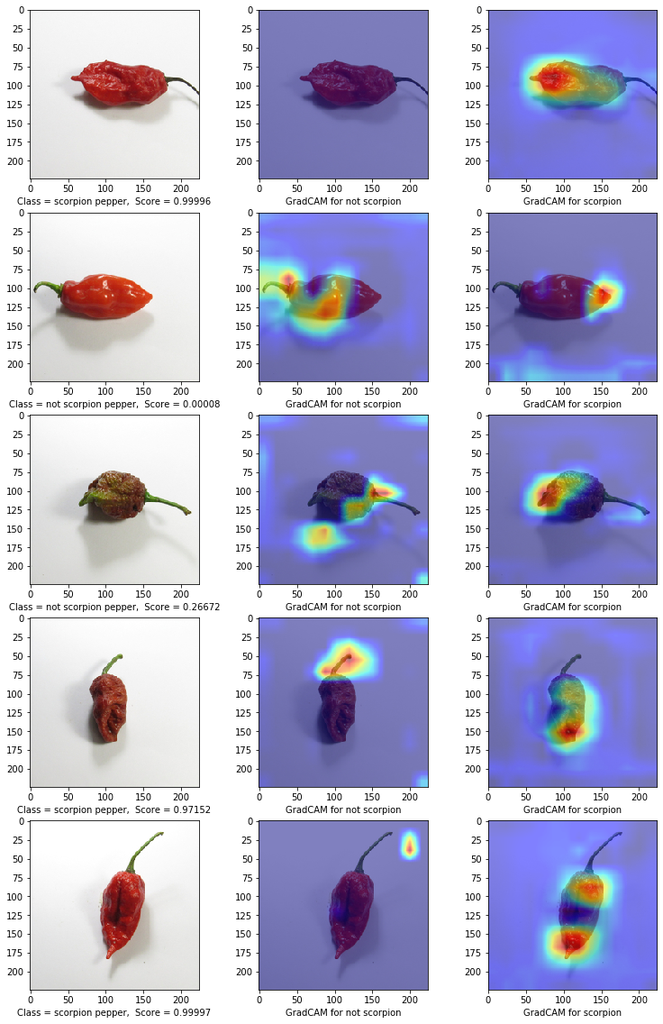

```python
# iterate through images in directory, generate Grad-CAM output, plot grid of the output images
for folder in dataset:
    i = 1
    columns = 3
    rows = 5 #change back to 5
    fig = plt.figure(figsize = (20, 20))

    for file in os.listdir(path+folder):
        img = image.load_img(path+folder+'\\'+file,target_size=(224, 224))
        x = image.img_to_array(img)
        # change x to appropriate shape: (1, 224, 224, 3)
        x = np.expand_dims(x, axis=0)
        # preprocessing step - rescale pixel color values between 0 and 1
        x /=255

        # change input shape and make prediction using model
        images = np.vstack([x])
        pred_y = model.predict(x, batch_size=1)
        print(pred_y)

        # Grad-CAM output for each class using layer: block5_conv3
        cam = grad_cam(model, 0, "block5_conv3", images)
        cam2 = grad_cam(model, 1, "block5_conv3", images)

        ax0 = fig.add_subplot(rows,columns,i)
        pred = float(pred_y[0][0])
        pred = "{0:.5f}".format(pred)
        ax0.set_xlabel('Class = {},  Score = {}'.format(isScorpion(pred_y[0][0]), pred))
        ax0.imshow(img)

        i = i+1
        ax1 = fig.add_subplot(rows,columns,i)
        pred = float(pred_y[0][0])
        pred = "{0:.5f}".format(pred)
        ax1.set_xlabel('GradCAM for not scorpion')
        ax1.imshow(img)
        ax1.imshow(cam, cmap='jet', alpha=0.5)

        i = i+1
        ax2 = fig.add_subplot(rows,columns, i)
        pred = float(pred_y[0][0])
        pred = "{0:.5f}".format(pred)
        ax2.set_xlabel('GradCAM for scorpion')
        ax2.imshow(img)
        ax2.imshow(cam2, cmap='jet', alpha=0.5)
        i=i+1

        #note left cannot be >= right
        fig.subplots_adjust(left=0, right=0.5)



del model
K.clear_session()  #seems to help with gpu memory leak in tensorflow 2.0
plt.show()
```